# Figure 1 graphs: Micronucleated chromosome length and gene density correlate with membrane rupture

Anna Mammel

11/5/2020

### Fig. 1D

```r
#Below are the programs that you will need to to run this script. However, you will need to import these programs first using the code:

#install.packages()

#Example > install.packages("knitr")

library(tidyverse)
library(readxl)
library(ggrepel)
```

#### Importing Data into R

MN_24h is the rupture frequency for MN containing a single chromosome for each replicate (N = 3 - 4)

MN_24h_pooled is the pooled rupture frequency for all replicates

```r
MN_24h <- read_xlsx("Mammel_et_al_2021_figure1_data.xlsx", sheet = 1)

MN_24h_pooled <- read_xlsx("Mammel_et_al_2021_figure1_data.xlsx", sheet = 2)
```

#### Changing chromosome and repliate to characters

R was reading these data as integers rather than characters. Which I needed to changes because this a categorical not continuous data

```r
MN_24h$chromosome <- as.character(MN_24h$chromosome)

MN_24h$replicate <- as.character(MN_24h$replicate)

MN_24h_pooled$chromosome <- as.character(MN_24h_pooled$chromosome)
```

#### Re-ordering the data

This is so that 1 and 4 come before chromosome 11

```r
MN_24h_reorder <- MN_24h %>%
  mutate(chromosome = fct_relevel(chromosome,
            "1", "4", "11","13", "15", "17", "18", "19", "20", "22"))

MN_24h_pooled_reorder <- MN_24h_pooled %>%
  mutate(chromosome = fct_relevel(chromosome,
            "1", "4", "11","13", "15", "17", "18", "19", "20", "22"))
```

#### Generating a theme for figures

This general theme will be used for all the graphs in the paper, for consistency.

```r
my_theme <- theme(axis.text.x   = element_text(size=12, color = "black", family = "sans"),
        axis.text.y = element_text(size=12, color = "black", family = "sans"),
        text=element_text(size = 12, family="sans"),
        axis.ticks= element_line(color = "black"),
        legend.position = "none")
```

#### These are the colors that will be used for each chromosome

These colors are color bind safe and re-ordered from the Safe R color pallet

```r
safe_v2 <- c("#332288", "#999933", "#882255", "#44AA99", "#CC6677", "#117733", "#88CCEE", "#DDCC77", "#AA4499","#888888")
```

#### Generating bar graph for percent intact for each chromosome at 24h post reversine treatment

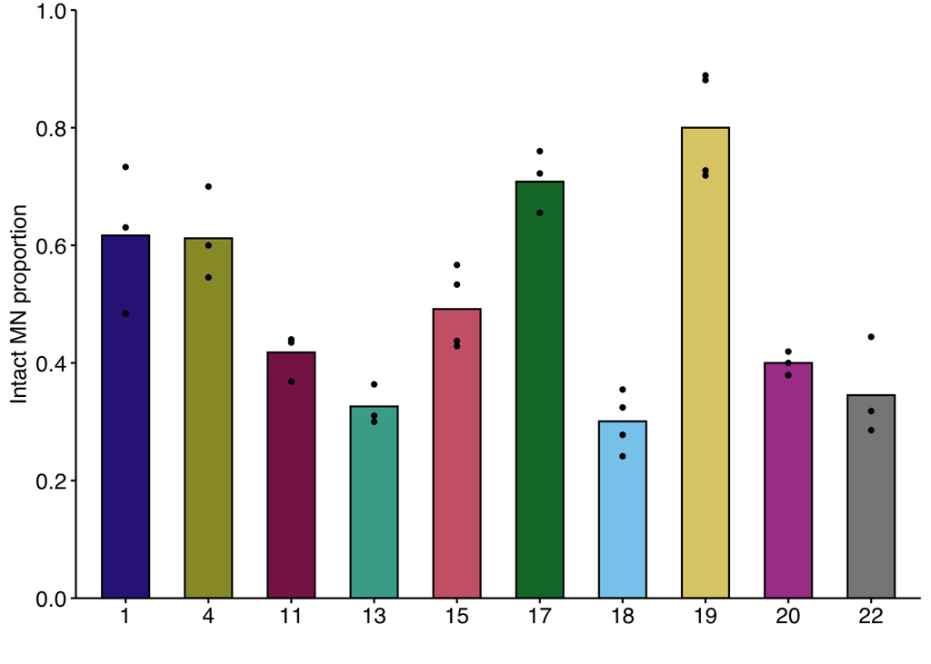

```r
rupture_freq_plot_MN_24h <- ggplot() +
  geom_col(data = MN_24h_pooled_reorder, aes(x = chromosome, y = `percent intact`, fill = chromosome), width = 0.57,
           color = "black", linesize = 0.5) +
  geom_point(data = MN_24h_reorder, mapping = aes(x = chromosome, y = `percent intact`), size = 1) +
  ylab('Intact MN proportion') +
  xlab('') +
  scale_y_continuous(expand = c(0,0), breaks = seq(0, 1, 0.2), limits = c(0,1)) +
  scale_fill_manual(values = safe_v2) +
  theme_classic() +
  my_theme

rupture_freq_plot_MN_24h
```

#### Chi-square

```r
MN_24h_intact_rupture <- MN_24h_pooled %>%
  select(intact:ruptured)

chisq.test(MN_24h_intact_rupture)
```

```
##
##  Pearson's Chi-squared test
##
## data:  MN_24h_intact_rupture
## X-squared = 112.63, df = 9, p-value < 2.2e-16
```

**Note: Similar ggplot and statistics were used for Fig. 1E, H, I, and J. Data included:**

- Fig. 1E = Sheet 3 (replicate) & 4 (pooled)
- Fig. 1I = Sheet 6 (replicate) & 7 (pooled)
- Fig. 1J = Sheet 8 (replicate) & 9 (pooled)

### Fig. 1F and G

Dataset includes chromosome feature information

```r
chr_gene <- read_xlsx("Mammel_et_al_2021_figure1_data.xlsx", sheet = 5)
```

#### Graph themes

```r
my_theme_2 <- theme(axis.text.x = element_text(size= 12, color = "black", family = "sans"),
        axis.text.y = element_text(size=12, color = "black", family = "sans"),
        text=element_text(size = 12, family="sans"),
        axis.ticks= element_line(color = "black"),
        strip.background = element_blank(),
        legend.position = c(1,1),
        legend.justification = c(1.1, 0.8),
        legend.title = element_text(size = 11),
        legend.background = element_blank(),
        legend.key.size = unit(0.2, "cm"),
        strip.text.x = element_blank())


my_theme_3 <- theme(axis.text.x = element_text(size=12, color = "black",
                                               family = "sans"),
        axis.text.y = element_text(size=12, color = "black", family = "sans"),
        text=element_text(size = 12, family="sans"),
        axis.ticks= element_line(color = "black"),
        strip.background = element_blank(),
        legend.position = c(0,1),
        legend.justification = c(0, 0.8),
        legend.title = element_text(size = 11),
        legend.background = element_blank(),
        legend.key.size = unit(0.2, "cm"),
        strip.text.x = element_blank())
```

#### Chromosome size correlates with rupture frequency plot

Controlling for gene density and comparing (20 - 24 genes/Mbp) chromosomes

```r
chr_gene_V2 <- chr_gene %>%
  filter(gene_range == "20-24")
```

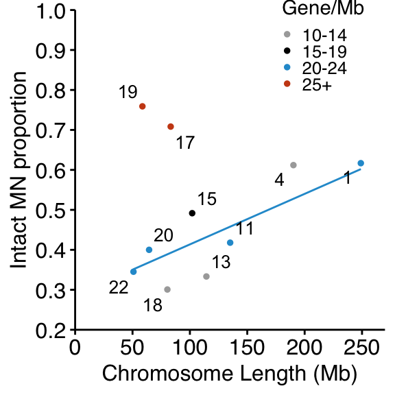

```r
rupture_freq_size_plot <-
  ggplot() +
  geom_point(data = chr_gene, size = 1, aes(group = gene_range,
                                            x = chromosome_size_bp*1e-06,
                       y = pooled, color = gene_range)) +
  geom_smooth(method = "glm", se = F, size = 0.5,show.legend = FALSE,
              aes(x = chr_gene_V2$chromosome_size_bp*1e-06,
                       y = chr_gene_V2$pooled, color = chr_gene_V2$gene_range)) +
  ylab('Intact MN proportion') +
  scale_y_continuous(expand = c(0,0),breaks = seq(0.2, 1, 0.1),
                     limits = c(0.2,1)) +
  scale_x_continuous(name = "Chromosome Length (Mb)", expand = c(0,0),
                     limits = c(0, 270)) +
  theme_classic() +
  geom_text_repel(aes(label = chr_gene$Chromosome,
                      x = chr_gene$chromosome_size_bp*1e-06,
                       y = chr_gene$pooled), color = "black", size = 3.5,
                  box_padding = 0.15) +
  scale_color_manual(values = c("dark gray","black","#269bd2", "#cb4b16"),
                     name = "Gene/Mb") +
  my_theme_2

rupture_freq_size_plot
```

```r
ggsave("rupture_freq_size_plot_V4.png", plot = rupture_freq_size_plot, units="in", dpi=600)
```

#### Gene Density correlates with rupture frequency plot

Controlling for chromosome size and comparing small (50 - 99 Mbp) chromosomes

```r
chr_gene <- chr_gene %>%
  mutate(size_group = fct_reorder(size_group, chromosome_size_bp))

chr_size_V1 <- chr_gene %>%
  filter(size_group == "50-99")
```

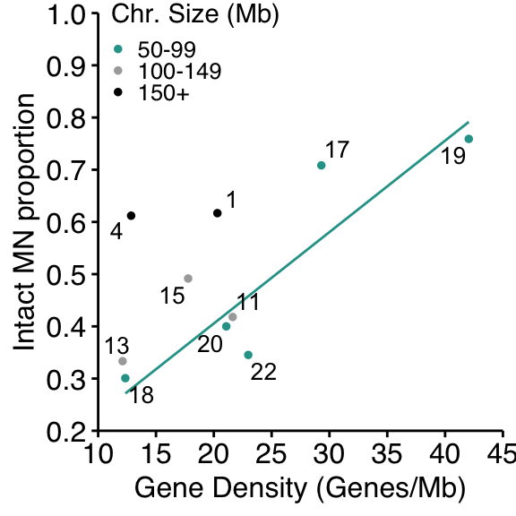

```r
rupture_freq_gene_plot <-
  ggplot() +
  geom_point(data = chr_gene, size = 1, aes(group = size_group, x = gene_Mb_2,
                    y = pooled, color = size_group)) +
  stat_smooth(method = "glm",se = F, size = 0.5, show.legend = FALSE,
              aes(x = chr_size_V1$gene_Mb_2, y = chr_size_V1$pooled,
                  color = chr_size_V1$size_group)) +
  ylab('Intact MN proportion') +
  scale_y_continuous(expand = c(0,0), breaks = seq(0, 1, 0.1),
                     limits = c(0.2,1)) +
  scale_x_continuous(name = "Gene Density (Genes/Mb)",
                     breaks = seq(0, 45, 5), limits = c(10,45),
                     expand = c(0,0)) +
  theme_classic() +
  geom_text_repel(aes(label = chr_gene$Chromosome, group = chr_gene$size_group,
                      x = chr_gene$gene_Mb_2, y = chr_gene$pooled),
                  color = "black", size = 3.5, box.padding = 0.15) +
  scale_color_manual(values = c("#2aa198", "dark gray", "black"),
                     name = "Chr. Size (Mb)") +
  my_theme_3

rupture_freq_gene_plot
```